# Pr3-Telnova

```python
import pandas as pd
import numpy as np
import matplotlib.pyplot as plt
import seaborn as sns
from sklearn.model_selection import train_test_split
```

```python
vw = pd.read_csv("vw.csv")
vw.shape
```

```
(15157, 9)
```

```python
vw.head()
```

|  | model | year | price | transmission | mileage | fuelType | tax | mpg | engineSize |
| --- | --- | --- | --- | --- | --- | --- | --- | --- | --- |
| 0 | T-Roc | 2019 | 25000 | Automatic | 13904 | Diesel | 145 | 49.6 | 2.0 |
| 1 | T-Roc | 2019 | 26883 | Automatic | 4562 | Diesel | 145 | 49.6 | 2.0 |
| 2 | T-Roc | 2019 | 20000 | Manual | 7414 | Diesel | 145 | 50.4 | 2.0 |
| 3 | T-Roc | 2019 | 33492 | Automatic | 4825 | Petrol | 145 | 32.5 | 2.0 |
| 4 | T-Roc | 2019 | 22900 | Semi-Auto | 6500 | Petrol | 150 | 39.8 | 1.5 |

```python
vw.info()
```

```
<class 'pandas.core.frame.DataFrame'>
RangeIndex: 15157 entries, 0 to 15156
Data columns (total 9 columns):
 #   Column        Non-Null Count  Dtype
---  ------        --------------  -----
 0   model         15157 non-null  object
 1   year          15157 non-null  int64
 2   price         15157 non-null  int64
 3   transmission  15157 non-null  object
 4   mileage       15157 non-null  int64
 5   fuelType      15157 non-null  object
 6   tax           15157 non-null  int64
 7   mpg           15157 non-null  float64
 8   engineSize    15157 non-null  float64
dtypes: float64(2), int64(4), object(3)
memory usage: 1.0+ MB
```

## Показатели набора

model - модель автомобиля  
year - год выпуска  
price - цена, £  
transmission - тип коробки передач: Automatic, Manual, Semi-Auto  
mileage - пробег, мили  
fuelType - тип топлива: Diesel, Petrol, Other, Hybrid  
tax - налог, £  
mpg - количество потребляемого топлива, мили/галлон  
engineSize - объем двигателя, литры

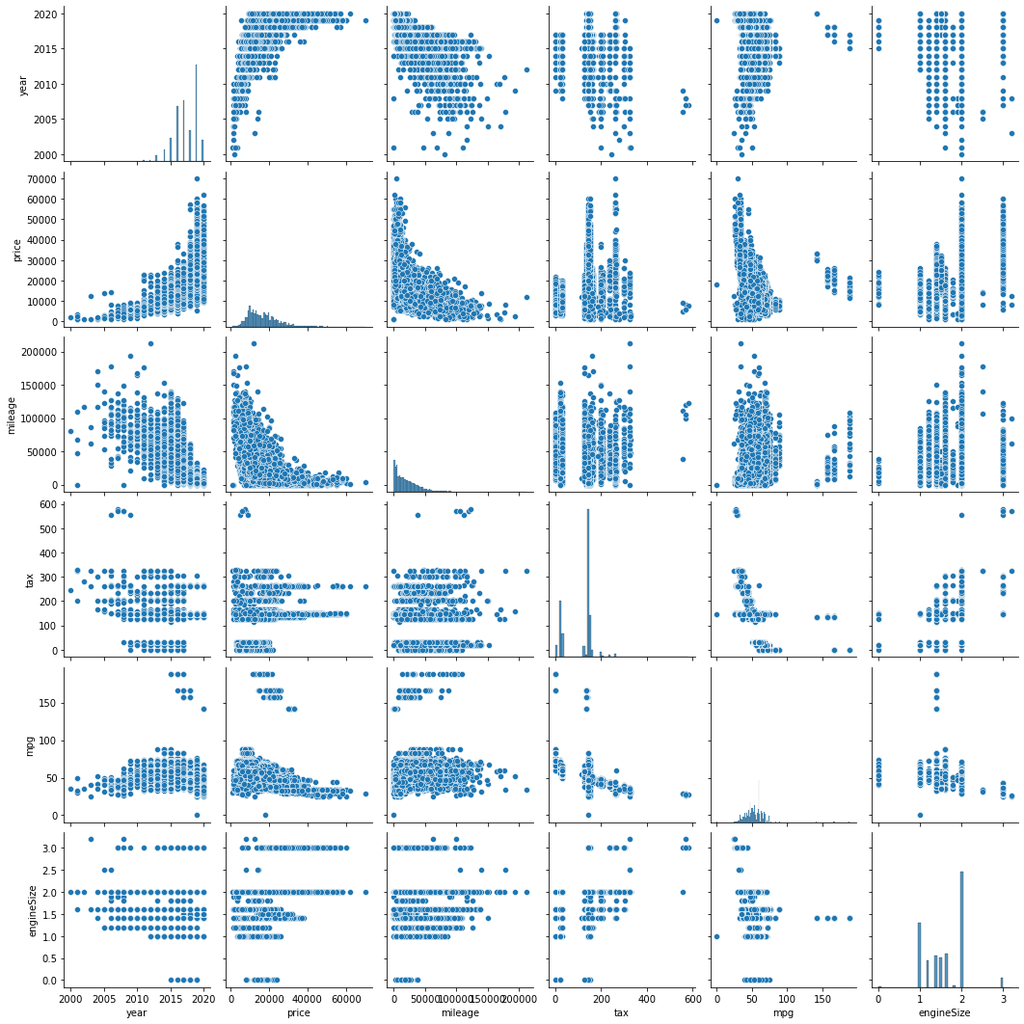

```python
sns.pairplot(vw)
```

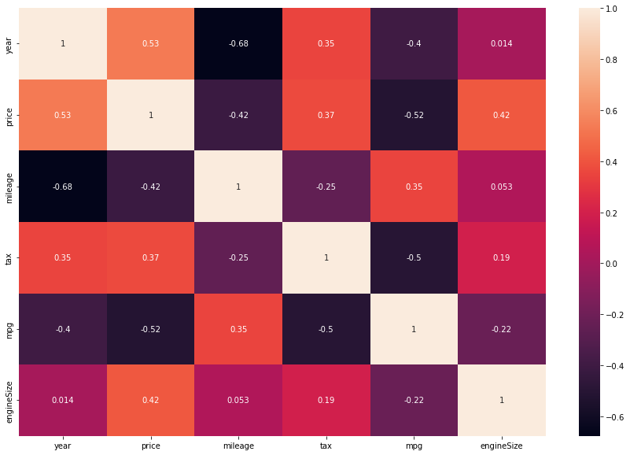

```python
# Коэффициенты корреляции
plt.figure(figsize = (15, 10))
sns.heatmap(vw.corr(method = 'kendall'), annot = True)
```

Диаграмма отражает величину связи между разными столбцами. Показатель price наиболее сильно (значение больше 0.4 по модулю) связан с показателями year, mileage, mpg, engineSize.

### Связь цены с количественным показателям

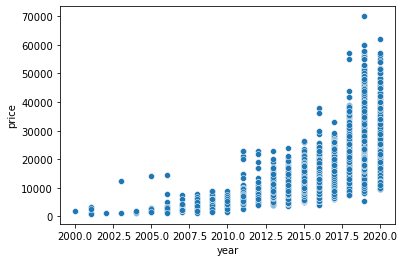

```python
sns.scatterplot(x = "year", y = "price", data = vw)
```

### Связь цены с качественными показателями

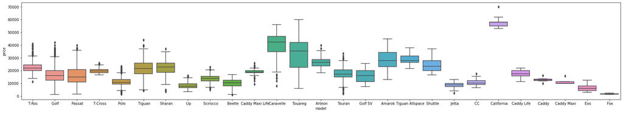

```python
plt.figure(figsize = (30, 5))
sns.boxplot(y = "price", x = "model", data = vw)
```

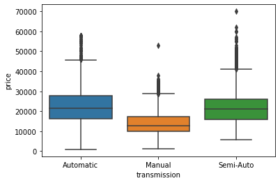

```python
sns.boxplot(y = "price", x = "transmission", data = vw)
```

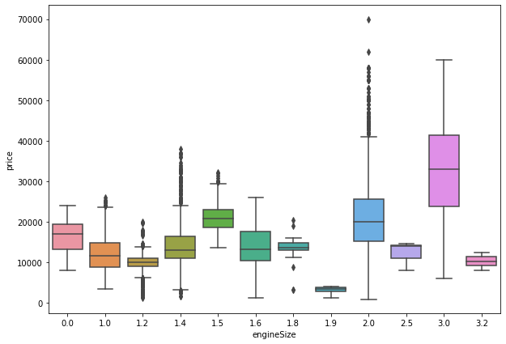

```python
plt.figure(figsize = (10, 7))
sns.boxplot(y = "price", x = "engineSize", data = vw)
```

## Подготовка обучающей и тестовой выборки

```python
X = vw.drop(columns=["price"])
Y = vw.price
X_train, X_test, Y_train, Y_test = train_test_split(X, Y, test_size=0.3, random_state=10)
print("Размер обучающей выборки X: ", X_train.shape)
print("Размер обучающей выборки Y: ", Y_train.shape)
print("Размер тестовой выборки X: ", X_test.shape)
print("Размер тестовой выборки Y: ", Y_test.shape)
```

```
Размер обучающей выборки X:  (10609, 8)
Размер обучающей выборки Y:  (10609,)
Размер тестовой выборки X:  (4548, 8)
Размер тестовой выборки Y:  (4548,)
```

## Построение регрессионных моделей

```python
import sklearn.metrics as metrics
from sklearn.linear_model import LinearRegression, Lasso, Ridge, LassoCV, RidgeCV
```

### 0. Базовая модель

```python
# средняя цена автомобиля
# X -> Y_train.mean()
Y_train.mean()
```

```
16877.77990385522
```

```python
# "улучшенная модель" - средняя цена автомобиля для разных моделей
# X -> if X[model] == Amarok: ...
train_data = pd.concat([X_train, Y_train], axis = 1)
dummy = train_data.groupby(["model"], as_index=False)["price"].mean()
dummy.rename(columns={"price": "mean price"}, inplace=True)
dummy.iloc[0:5]
```

|  | model | mean price |
| --- | --- | --- |
| 0 | Amarok | 27912.405063 |
| 1 | Arteon | 26481.000000 |
| 2 | Beetle | 9474.527273 |
| 3 | CC | 10702.223881 |
| 4 | Caddy | 13413.800000 |

```python
# вычислим ошибку при прогнозе цены автомобиля по средней для разных моделей
Y_test_dummy = pd.merge(X_test, dummy, on="model")["mean price"]
metrics.mean_squared_error(Y_test, Y_test_dummy, squared = False)
```

```
9519.618186423353
```

### 1. Прогноз по одному показателю

```python
LR_One = LinearRegression()
# обучение модели на данных
X_train_One = X_train["year"].values.reshape(-1, 1)
X_test_One = X_test["year"].values.reshape(-1, 1)
LR_One.fit(X_train_One, Y_train)
# вычисление прогноза на тестовых данных
Y_test_LR_One = LR_One.predict(X_test_One)
# вычисление ошибки
metrics.mean_squared_error(Y_test, Y_test_LR_One, squared = False)
```

```
5977.879437066637
```

Ошибка меньше, чем полученная на предыдущем шаге.

```python
# y = a*x + b
# коэффициенты модели
print("Смещение = ", LR_One.intercept_)
print("Коэффициент = ", LR_One.coef_)
```

```
Смещение =  -4719692.375077385
Коэффициент =  [2348.00929023]
```

```python
# расчитаем прогнозируемое значение "вручную"
y_manual = LR_One.intercept_ + X_test["year"][0:10] * LR_One.coef_
res = pd.DataFrame({ "predicted calculated" : y_manual, "predicted" : Y_test_LR_One[0:10], "real" : Y_test[0:10], "model" : X_test.model[0:10] })
pd.merge(res, dummy, on="model").drop(columns=["model"])
```

|  | predicted calculated | predicted | real | mean price |
| --- | --- | --- | --- | --- |
| 0 | 16242.363307 | 16242.363307 | 6399 | 8088.925566 |
| 1 | 18590.372598 | 18590.372598 | 7952 | 8088.925566 |
| 2 | 13894.354017 | 13894.354017 | 10999 | 15957.010695 |
| 3 | 11546.344727 | 11546.344727 | 8995 | 15957.010695 |
| 4 | 16242.363307 | 16242.363307 | 16700 | 16692.646512 |
| 5 | 13894.354017 | 13894.354017 | 9890 | 11405.594466 |
| 6 | 13894.354017 | 13894.354017 | 15499 | 16671.215357 |
| 7 | 11546.344727 | 11546.344727 | 11399 | 16671.215357 |
| 8 | 16242.363307 | 16242.363307 | 16998 | 16671.215357 |
| 9 | 18590.372598 | 18590.372598 | 22788 | 27912.405063 |

Прогноз цены автомобиля по одному показателю year очень неточный. Кажется, что вычисление цены как средней по всем автомобилям одной модели в результате оказывается лучше. Но на самом деле это дает еще более неточный результат.

### 2. Прогноз по всем показателям

```python
LR_All = LinearRegression()
# обучение модели на данных
LR_All.fit(X_train.drop(columns=["model", "transmission", "fuelType"]), Y_train)
# вычисление прогноза на тестовых данных
Y_test_LR_All = LR_All.predict(X_test.drop(columns=["model", "transmission", "fuelType"]))
# вычисление ошибки
metrics.mean_squared_error(Y_test, Y_test_LR_All, squared = False)
```

```
3733.318700833648
```

Значение ошибки уменьшилось с почти 6000 до 3700.

```python
pd.Series(LR_All.coef_, index=X_train.drop(columns=["model", "transmission", "fuelType"]).columns)
```

```
year          1474.465315
mileage         -0.085598
tax              3.108863
mpg            -80.207646
engineSize    9337.941769
dtype: float64
```

```python
pd.DataFrame({ "predicted one" : Y_test_LR_One[0:5], "predicted all" : Y_test_LR_All[0:5], "real" : Y_test[0:5] })
```

|  | predicted one | predicted all | real |
| --- | --- | --- | --- |
| 12917 | 16242.363307 | 9614.270408 | 6399 |
| 14551 | 13894.354017 | 17230.081257 | 10999 |
| 6345 | 16242.363307 | 15164.259079 | 16700 |
| 8023 | 13894.354017 | 11376.437363 | 9890 |
| 4481 | 13894.354017 | 15189.872946 | 15499 |

Прогноз по нескольким показателям работает лучше, чем прогноз по одному показателю. При этом он все равно недостаточно точный.

### 3. Нормировка данных

```python
# нормировка
from sklearn.preprocessing import StandardScaler
from sklearn.preprocessing import MinMaxScaler

stdScaler = StandardScaler()
X_train_scaled = stdScaler.fit_transform(X_train.drop(columns=["model", "transmission", "fuelType"]))
X_test_scaled = stdScaler.transform(X_test.drop(columns=["model", "transmission", "fuelType"]))
pd.DataFrame(X_train_scaled).head()
```

|  | 0 | 1 | 2 | 3 | 4 |
| --- | --- | --- | --- | --- | --- |
| 0 | -0.133216 | -0.674664 | 0.513913 | 1.508169 | -0.008095 |
| 1 | 1.343579 | -1.038385 | 0.592536 | -0.428670 | -1.302794 |
| 2 | 0.851314 | -0.964963 | 0.513913 | -0.656102 | -0.223878 |
| 3 | 0.851314 | -0.559494 | 0.513913 | -0.751476 | -0.223878 |
| 4 | 0.359049 | -0.258464 | 0.435290 | 8.250424 | -0.439661 |

```python
LR_StdScaled = LinearRegression()
# обучение модели на данных
LR_StdScaled.fit(X_train_scaled, Y_train)
# вычисление прогноза на тестовых данных
Y_test_LR_StdScaled = LR_StdScaled.predict(X_test_scaled)
# вычисление ошибки
metrics.mean_squared_error(Y_test, Y_test_LR_StdScaled, squared = False)
```

```
3733.31870083363
```

Получили то же самое значение ошибки, как и перед нормировкой.

```python
pd.Series(LR_StdScaled.coef_, index=X_train.drop(columns=["model", "transmission", "fuelType"]).columns)
```

```
year          2995.266525
mileage      -1818.711470
tax            197.707242
mpg          -1093.266784
engineSize    4327.466889
dtype: float64
```

Получается, показатель engineSize сильнее влияет на цену автомобиля, чем year.

### 4. Регуляризация

```python
# Модель линейной регрессии с регуляризацией типа "Lasso" - L1
# Использование "Ridge" с L2 резуляризацией проводит к большей ошибке
LR_lasso = Lasso()
LR_lasso.fit(X_train_scaled, Y_train)
Y_test_lasso = LR_lasso.predict(X_test_scaled)
metrics.mean_squared_error(Y_test_lasso, Y_test, squared=False)
```

```
3733.251618268206
```

Получили значение ошибки на 0.07 меньше, чем при построении прогноза по всем показателям.

```python
pd.Series(LR_lasso.coef_, index=X_train.drop(columns=["model", "transmission", "fuelType"]).columns)
```

```
year          2995.390820
mileage      -1817.703099
tax            197.429257
mpg          -1092.973358
engineSize    4326.509405
dtype: float64
```

### 5. Обработка качественных показателей

```python
# количество автомобилей определенной модели
vw.model.value_counts()
```

```
 Golf               4863
 Polo               3287
 Tiguan             1765
 Passat              915
 Up                  884
 T-Roc               733
 Touareg             363
 Touran              352
 T-Cross             300
 Golf SV             268
 Sharan              260
 Arteon              248
 Scirocco            242
 Amarok              111
 Caravelle           101
 CC                   95
 Tiguan Allspace      91
 Beetle               83
 Shuttle              61
 Caddy Maxi Life      59
 Jetta                32
 California           15
 Caddy Life            8
 Eos                   7
 Caddy                 6
 Caddy Maxi            4
 Fox                   4
Name: model, dtype: int64
```

```python
# объем двигателя и количество автомобилей с ним
vw.engineSize.value_counts()
```

```
2.0    5570
1.0    3121
1.6    1629
1.4    1536
1.5    1446
1.2    1304
3.0     450
1.8      77
0.0      15
1.9       4
2.5       3
3.2       2
Name: engineSize, dtype: int64
```

```python
# преобразование качественных показателей
# vw_add = pd.get_dummies(vw, columns=["model", "transmission", "fuelType", "engineSize"], prefix="", prefix_sep="")
vw_add = pd.get_dummies(vw, columns=["model", "transmission", "fuelType"], prefix="", prefix_sep="")
vw_add.iloc[0:5,:]
```

|  | year | price | mileage | tax | mpg | engineSize | Amarok | Arteon | Beetle | CC | ... | Touareg | Touran | Up | Automatic | Manual | Semi-Auto | Diesel | Hybrid | Other | Petrol |
| --- | --- | --- | --- | --- | --- | --- | --- | --- | --- | --- | --- | --- | --- | --- | --- | --- | --- | --- | --- | --- | --- |
| 0 | 2019 | 25000 | 13904 | 145 | 49.6 | 2.0 | 0 | 0 | 0 | 0 | ... | 0 | 0 | 0 | 1 | 0 | 0 | 1 | 0 | 0 | 0 |
| 1 | 2019 | 26883 | 4562 | 145 | 49.6 | 2.0 | 0 | 0 | 0 | 0 | ... | 0 | 0 | 0 | 1 | 0 | 0 | 1 | 0 | 0 | 0 |
| 2 | 2019 | 20000 | 7414 | 145 | 50.4 | 2.0 | 0 | 0 | 0 | 0 | ... | 0 | 0 | 0 | 0 | 1 | 0 | 1 | 0 | 0 | 0 |
| 3 | 2019 | 33492 | 4825 | 145 | 32.5 | 2.0 | 0 | 0 | 0 | 0 | ... | 0 | 0 | 0 | 1 | 0 | 0 | 0 | 0 | 0 | 1 |
| 4 | 2019 | 22900 | 6500 | 150 | 39.8 | 1.5 | 0 | 0 | 0 | 0 | ... | 0 | 0 | 0 | 0 | 0 | 1 | 0 | 0 | 0 | 1 |

5 rows × 40 columns

```python
# объединение некоторых схожих моделей автомобилей, чья средняя стоимость не сильно отличается, в группы
vw_add[" Caddy All"] = vw_add[[" Caddy"," Caddy Maxi"," Caddy Life"," Caddy Maxi Life"]].sum(axis=1)
vw_add[" Tiguan All"] = vw_add[[" Tiguan"," Tiguan Allspace"]].sum(axis=1)

# в отдельную группу объединим модели, которые представлены небольшим количеством автомобилей
# для них также средняя стоимость не должна сильно отличаться
vw_add[" Others All"] = vw_add[[" Fox"," Eos"," Jetta"," CC"]].sum(axis=1)

vw_add = vw_add.drop(columns=[" Caddy"," Caddy Maxi"," Caddy Life"," Caddy Maxi Life"," Tiguan"," Tiguan Allspace"," Fox"," Eos"," Jetta"," CC"])

# объединим объемы двигателей в 3 группы:
# vw_add["0.0-1.4"] = vw_add[["0.0","1.0","1.2","1.4"]].sum(axis=1)
# vw_add["1.5-1.9"] = vw_add[["1.5","1.6","1.8","1.9"]].sum(axis=1)
# vw_add["2.0-3.2"] = vw_add[["2.0","2.5","3.0","3.2"]].sum(axis=1)
# vw_add = vw_add.drop(columns=["0.0","1.0","1.2","1.4","1.5","1.6","1.8","1.9","2.0","2.5","3.0","3.2"])
vw_add.iloc[0:5]
```

|  | year | price | mileage | tax | mpg | engineSize | Amarok | Arteon | Beetle | California | ... | Automatic | Manual | Semi-Auto | Diesel | Hybrid | Other | Petrol | Caddy All | Tiguan All | Others All |
| --- | --- | --- | --- | --- | --- | --- | --- | --- | --- | --- | --- | --- | --- | --- | --- | --- | --- | --- | --- | --- | --- |
| 0 | 2019 | 25000 | 13904 | 145 | 49.6 | 2.0 | 0 | 0 | 0 | 0 | ... | 1 | 0 | 0 | 1 | 0 | 0 | 0 | 0 | 0 | 0 |
| 1 | 2019 | 26883 | 4562 | 145 | 49.6 | 2.0 | 0 | 0 | 0 | 0 | ... | 1 | 0 | 0 | 1 | 0 | 0 | 0 | 0 | 0 | 0 |
| 2 | 2019 | 20000 | 7414 | 145 | 50.4 | 2.0 | 0 | 0 | 0 | 0 | ... | 0 | 1 | 0 | 1 | 0 | 0 | 0 | 0 | 0 | 0 |
| 3 | 2019 | 33492 | 4825 | 145 | 32.5 | 2.0 | 0 | 0 | 0 | 0 | ... | 1 | 0 | 0 | 0 | 0 | 0 | 1 | 0 | 0 | 0 |
| 4 | 2019 | 22900 | 6500 | 150 | 39.8 | 1.5 | 0 | 0 | 0 | 0 | ... | 0 | 0 | 1 | 0 | 0 | 0 | 1 | 0 | 0 | 0 |

5 rows × 33 columns

```python
X_add = vw_add.drop(columns=["price"])
Y_add = vw_add.price
X_train_add, X_test_add, Y_train_add, Y_test_add = train_test_split(X_add, Y_add, test_size=0.3, random_state=10)
```

```python
LR_All_add = LinearRegression()
# обучение модели на данных
LR_All_add.fit(X_train_add, Y_train_add)
# вычисление прогноза на тестовых данных
Y_test_LR_All_add = LR_All_add.predict(X_test_add)
# вычисление ошибки
metrics.mean_squared_error(Y_test_LR_All_add, Y_test_add, squared = False)
```

```
2534.408690483796
```

Если рассматривать показатель engineSize не как количественный, а как качественный, при этом объединив значения объемов в 3 группы (закомментированные строки), то ошибка будет близка к полученной, но чуть больше.

```python
pd.DataFrame({ "predicted all" : Y_test_LR_All[0:10], "predicted all with add" : Y_test_LR_All_add[0:10], "real" : Y_test[0:10] })
```

|  | predicted all | predicted all with add | real |
| --- | --- | --- | --- |
| 12917 | 9614.270408 | 7919.659203 | 6399 |
| 14551 | 17230.081257 | 13882.485414 | 10999 |
| 6345 | 15164.259079 | 15171.320839 | 16700 |
| 8023 | 11376.437363 | 11405.983641 | 9890 |
| 4481 | 15189.872946 | 15262.389246 | 15499 |
| 14520 | 12012.994186 | 9198.105285 | 8995 |
| 4896 | 15792.794627 | 14072.474809 | 11399 |
| 2194 | 1800.567198 | 14735.904153 | 16998 |
| 12385 | 12832.624068 | 9208.133906 | 7952 |
| 14762 | 34559.604886 | 29457.443082 | 22788 |

Точность прогноза с качственными показателями выше, чем без них. Ошибка уменьшилась с почти 3700 до 2500.

### 6. Другие рергессионные модели

```python
# регрессор на базе случайного леса
# без использования качественных показателей
from sklearn.ensemble import RandomForestRegressor

RF_model = RandomForestRegressor(random_state = 10, n_estimators = 100)
RF_model.fit(X_train.drop(columns=["model", "transmission", "fuelType"]), Y_train)
Y_test_RF = RF_model.predict(X_test.drop(columns=["model", "transmission", "fuelType"]))
metrics.mean_squared_error(Y_test_RF, Y_test, squared=False)
```

```
2176.803672142748
```

```python
# с использованием качественных показателей
RF_model_add = RandomForestRegressor(random_state = 10, n_estimators = 100)
RF_model_add.fit(X_train_add, Y_train_add)
Y_test_RF_add = RF_model_add.predict(X_test_add)
metrics.mean_squared_error(Y_test_RF_add, Y_test_add, squared=False)
```

```
1723.4258509741294
```

Ошибка стала еще меньше.

```python
# оценки важности показателей с точки зрения модели RandomForest
# только количественные показатели
RF_model.feature_importances_
```

```
array([0.17649969, 0.07542628, 0.01980003, 0.61091276, 0.11736124])
```

```python
# количественные и качественные показатели
RF_model_add.feature_importances_
```

```
array([1.66000855e-01, 5.78686540e-02, 1.25660856e-02, 5.74240756e-01,
       1.04070723e-01, 2.27110273e-03, 2.06476191e-03, 2.76491671e-04,
       3.55836560e-03, 3.30882423e-03, 2.47168387e-03, 5.43988400e-04,
       1.47369108e-03, 5.65525046e-03, 1.00598971e-03, 5.90330469e-04,
       1.66249945e-03, 2.87623430e-03, 4.43410978e-03, 3.38694497e-03,
       1.49002083e-03, 7.40076073e-03, 1.26454264e-03, 5.19270844e-03,
       1.50413213e-03, 9.51226991e-03, 1.46999761e-03, 1.19297607e-04,
       1.56632188e-02, 6.99506671e-04, 4.92512454e-03, 4.31078535e-04])
```

В обоих случаях с точки зрения этой модели наиболее важный показатель - mpg (количество потребляемого топлива) - 4 показатель.

```python
# Полиномиальная регрессия
# y = b + a1 * x1 + a2 * x2 + a12 * x1 * x2 +  a1s * x1^2 + .. .. ..

from sklearn.preprocessing import PolynomialFeatures

poly = PolynomialFeatures(2, include_bias=False)
poly_df = poly.fit_transform(vw_add.drop(columns=["price"]))
scaled_poly_df = stdScaler.fit_transform(poly_df)
print(f"shape: {scaled_poly_df.shape}")

PolyModel = LinearRegression()
PolyModel.fit(scaled_poly_df, vw_add.price)
predictions = PolyModel.predict(scaled_poly_df)
mse = metrics.mean_squared_error(vw_add.price, predictions, squared=False)
print("RMSE: {}".format(mse))
```

```
shape: (15157, 560)
RMSE: 1783.0104771007238
```

По сравнению с регрессором на базе случайного леса точность незначительно, но ухудшилась. А количество показателей стало значительно больше.

### Сравнение моделей

```python
pd.DataFrame({ "LR_One" : Y_test_LR_One[0:10], "LR_All" : Y_test_LR_All[0:10], "Lasso" : Y_test_lasso[0:10], "LR_All_add" : Y_test_LR_All_add[0:10], "RF_add" : Y_test_RF_add[0:10], "real" : Y_test[0:10] })
```

|  | LR_One | LR_All | Lasso | LR_All_add | RF_add | real |
| --- | --- | --- | --- | --- | --- | --- |
| 12917 | 16242.363307 | 9614.270408 | 9616.185879 | 7919.659203 | 7257.410000 | 6399 |
| 14551 | 13894.354017 | 17230.081257 | 17229.945879 | 13882.485414 | 13482.790000 | 10999 |
| 6345 | 16242.363307 | 15164.259079 | 15164.283992 | 15171.320839 | 16201.743333 | 16700 |
| 8023 | 13894.354017 | 11376.437363 | 11377.213441 | 11405.983641 | 9862.730000 | 9890 |
| 4481 | 13894.354017 | 15189.872946 | 15190.935282 | 15262.389246 | 13317.690000 | 15499 |
| 14520 | 11546.344727 | 12012.994186 | 12014.872691 | 9198.105285 | 9505.090000 | 8995 |
| 4896 | 11546.344727 | 15792.794627 | 15792.530506 | 14072.474809 | 11158.210000 | 11399 |
| 2194 | 16242.363307 | 1800.567198 | 1805.628117 | 14735.904153 | 16749.510000 | 16998 |
| 12385 | 18590.372598 | 12832.624068 | 12833.302901 | 9208.133906 | 8878.490000 | 7952 |
| 14762 | 18590.372598 | 34559.604886 | 34554.882722 | 29457.443082 | 32038.280000 | 22788 |

Наиболее точно делает прогноз цены автомобиля модель на базе случайного леса с использованием количественных и качественных показателей (RF_add). Наименьшая ошибка - 1723.43 £.